# From Chaos to Continents

Procedural Terrain Generation Using Voronoi Diagrams and More

Author

Batsambuu Batbold

Published

December 1, 2025

Abstract

[figure not shown]

# Introduction

As a fan of open-world and simulation video games, the setting and environment are the biggest factors in deciding if a virtual world is worth my time. We, as players, expect vast, immersive, and explorable worlds that offer a unique experience. Who wants to keep coming back to the same place if it offers nothing new? However, hand-crafting these worlds is a massive undertaking. It often takes longer to build than it takes to walk across them. This is why **Procedural Content Generation** (PCG) is essential to reduce creation time and increase replayability.

Every game has its own unique story and gameplay, requiring different types of worlds. Traditional PCG methods often use square grids (like Minecraft) or hexagons (like Civilization). While these are computationally easy to handle, they obviously lack a natural feel. I wanted terrain that feels organic and looks natural, but follows consistent rules to satisfy my specific vision.

**I wanted *my world* to be shaped in *my way*.**

In this project, we explore a way to procedurally generate a 3D terrain using computational geometry:

1. First, we generate a 2D map, adapting ideas from Amit Patel’s **Red Blob Games** [1] and tweaking the logic to fit our specific goals.
2. Then, we prepare and convert the 2D map data into a heightmap for 3D terrain.
3. Finally, we transfer the data to Blender to render and build the cinematic world.

# Stage 1: Chaos

It all starts with the chaos of random points.

To generate a 2D map, we first need small cells that essentially serve as the “pixels” or building blocks of our world. However, as mentioned earlier, usual square and hexagonal grids don’t result in realistic looking landscapes. Using polygons of varying shapes helps us generate a map that feels less engineered and more organic.

So, we call upon our old friend: the **Voronoi Diagram**.

## Voronoi Diagram

Given a point cloud $S$ on a plane, a Voronoi Diagram partitions the plane into regions. For any given point $p$, its Voronoi region consists of all points in the plane that are closer to $p$ than to any other point. Mathematically:

$$\text{Vor}(p) = \{x \in \mathbb{R}^2 \:| \: \|x-p\| \leq \|x-q\| \text{ for all } q \in S \}$$

These regions create convex polygons that tile the plane. In the context of terrain generation, each of these Voronoi regions becomes a distinct territory: a patch of forest, a slice of ocean, or a mountain peak. To actually compute these regions in code, we turn to the dual of the Voronoi diagram: the **Delaunay Triangulation**.

## Delaunay Triangulation

Delaunay Triangulation is defined as a triangulation of a set of points where no point is inside the circumcircle of any triangle. It is mathematically linked to the Voronoi Diagram via duality. If we connect every pair of points whose Voronoi regions share an edge, we get the Delaunay Triangulation. Conversely, the circumcenters of the Delaunay triangles serve as the vertices of the Voronoi diagram.

For the implementation, I used the popular existing library **delaunator** [2]. It computes the triangulation efficiently, allowing us to derive the Voronoi region boundaries from the triangle centers.

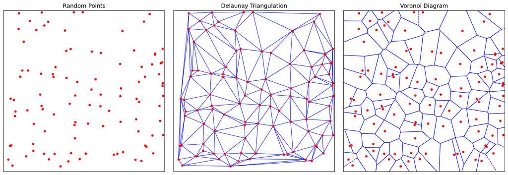

Figure 2: Delaunay Triangulation and Voronoi Regions for 100 random points.

As seen in Figure 2, the polygons look nice and random. However, they might be *too random*. True randomness is clumpy. We end up with tiny slivers of polygons right next to massive, stretched-out ones. This is too chaotic to be a skeleton for a game world. We want the terrain to be somewhat smoother and more uniform, mimicking the organic beauty of nature. To fix the clumping, we use **Lloyd’s Relaxation** [3], also known as Voronoi iteration.

## Lloyd’s Relaxation

Lloyd’s Relaxation is a simple algorithm that moves the random points to space them out evenly:

1. Compute the Voronoi Diagram of the current points.
2. Calculate the centroid of each Voronoi region.
3. Move the point to that centroid.
4. Repeat.

By repeating this process a few times, the points naturally space themselves out. After each iteration, the Voronoi cells become more uniform, ultimately resembling a turtle shell like pattern. I used the existing package **lloyd** [4] to handle this calculation.

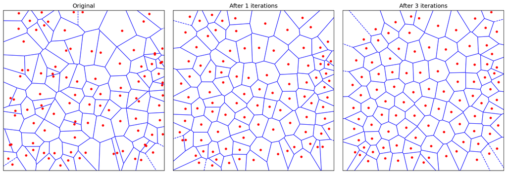

Figure 3: Lloyd’s Relaxation after 1 and 3 iterations. Typically, 2–3 iterations are sufficient to stabilize the mesh.

Now, our grid is done, and it’s time to create the land.

# Stage 2: Creation

## Perlin Noise

[figure not shown]

# Biome Assignment

[figure not shown]

# 2D Interactive Playground

[figure not shown]

# Effect of Parameters

## Noise Scale

[figure not shown]

## Water Level

[figure not shown]

## Island Clusters

[figure not shown]

# Transfer to 3D

[figure not shown]

## 3D Result

[figure not shown]

# Key Insights

# Limitations

# Future Work

Ideas to consider:

- Rivers and watersheds
- More realistic biomes (temperature + moisture)
- Erosion simulation
- City/road placement
- Real-time 3D rendering

# Conclusion

# Note

# References

[1]

A. Patel, “Polygonal map generation for games.” https://www.redblobgames.com/maps/terrain-from-noise/, 2015.

[2]

Mapbox, “Delaunator: Fast delaunay triangulation.” https://github.com/mapbox/delaunator.

[3]

M. McClure, “Lloyd relaxation of voronoi diagrams.” https://demonstrations.wolfram.com/LloydRelaxationOfVoronoiDiagrams/; Wolfram Demonstrations Project, 2024.

[4]

E. Duhaime, “Lloyd: Lloyd’s relaxation for voronoi diagrams,” *GitHub repository*. https://github.com/duhaime/lloyd; GitHub, 2015.